# Case study #1 : Airline Safety data

## Setup

This case study is based on an [article](https://fivethirtyeight.com/features/should-travelers-avoid-flying-airlines-that-have-had-crashes-in-the-past/) from [FiveThirtyEight](https://fivethirtyeight.com/) published by [Nate Silver](https://fivethirtyeight.com/contributors/nate-silver/). Using [data](https://github.com/fivethirtyeight/data/tree/master/airline-safety)[^1] from the [Aviation Safety Network’s database](https://aviation-safety.net/index.php), we want to see if past safety records can predict future risk of accidents. In other words “Should Travelers Avoid Flying Airlines That Have Had Crashes in the Past?”

## The Questions!

This next code chunk loads the data for you:

```r
# load data ScPoEconometrics package
if (packageVersion("ScPoEconometrics") > "0.2.3"){
    data=read.csv(system.file(package = "ScPoEconometrics", "datasets", "airline-safety.csv"))
} else {
    data=read.csv(file = "https://raw.githubusercontent.com/ScPoEcon/ScPoEconometrics/master/inst/datasets/airline-safety.csv")
}
```

## Exploring the data

The dataset contains the safety records of major commercial airlines over the past 30 years (1985 to 2014). The period has been break down into two halves: from 1985 to 1999, and from 2000 to 2014.

1. First look at the dataset
   1. What are the variables names and types (categorical, numerical, …) included in the data ?

      ```r
      #names(data)
      str(data)
      ```

      ```
      ## 'data.frame':    336 obs. of  5 variables:
      ##  $ airline               : Factor w/ 56 levels "Aer Lingus","Aeroflot*",..: 1 2 3 4 5 6 7 8 9 10 ...
      ##  $ avail_seat_km_per_week: num  3.21e+08 1.20e+09 3.86e+08 5.97e+08 1.87e+09 ...
      ##  $ type                  : Factor w/ 3 levels "fatal_accidents",..: 3 3 3 3 3 3 3 3 3 3 ...
      ##  $ value                 : int  2 76 6 3 2 14 2 3 5 7 ...
      ##  $ period                : Factor w/ 2 levels "1985_1999","2000_2014": 1 1 1 1 1 1 1 1 1 1 ...
      ```

   2. What is the number of observations in total?

      ```r
      dim(data)[1]
      ```

      ```
      ## [1] 336
      ```

   3. What defines an observation in our case (no need to code) ?
2. Having a closer look
   1. How does the dataset look like : have a look to the first 5 observations, and the bottom 5.

      ```r
      head(data)
      ```

      ```
      ##                 airline avail_seat_km_per_week      type value    period
      ## 1            Aer Lingus              320906734 incidents     2 1985_1999
      ## 2             Aeroflot*             1197672318 incidents    76 1985_1999
      ## 3 Aerolineas Argentinas              385803648 incidents     6 1985_1999
      ## 4           Aeromexico*              596871813 incidents     3 1985_1999
      ## 5            Air Canada             1865253802 incidents     2 1985_1999
      ## 6            Air France             3004002661 incidents    14 1985_1999
      ```

      ```r
      tail(data)
      ```

      ```
      ##                        airline avail_seat_km_per_week       type value
      ## 331           Turkish Airlines             1946098294 fatalities    84
      ## 332      United / Continental*             7139291291 fatalities   109
      ## 333 US Airways / America West*             2455687887 fatalities    23
      ## 334           Vietnam Airlines              625084918 fatalities     0
      ## 335            Virgin Atlantic             1005248585 fatalities     0
      ## 336            Xiamen Airlines              430462962 fatalities     0
      ##        period
      ## 331 2000_2014
      ## 332 2000_2014
      ## 333 2000_2014
      ## 334 2000_2014
      ## 335 2000_2014
      ## 336 2000_2014
      ```

   2. What are the different values of the `type` variable ? Same question for the `period variable.

      ```r
      table(data$type, useNA = "ifany")
      ```

      ```
      ##
      ## fatal_accidents      fatalities       incidents
      ##             112             112             112
      ```

      ```r
      table(data$period, useNA = "ifany")
      ```

      ```
      ##
      ## 1985_1999 2000_2014
      ##       168       168
      ```

   3. Is there any NA’s in the dataset ?

      ```r
      sum(is.na(data))
      ```

      ```
      ## [1] 0
      ```

      ```r
      apply(data, 2, function(x) any(is.na(x)))
      ```

      ```
      ##                airline avail_seat_km_per_week                   type
      ##                  FALSE                  FALSE                  FALSE
      ##                  value                 period
      ##                  FALSE                  FALSE
      ```

   4. The `avail_seat_km_per_week` variable corresponds to the number of seats multiplied by the number of kilometers the airline flies in a week. In your opinion, why could this variable be important for future analysis ?

## Analysis

1. What are the mean value of the number of incidents by `type` and `period` ? Same for the standard deviation ?

   ```r
   data %>%
     group_by(period, type) %>%
     summarise(mean_fatal_by_period = mean(value),
               sd_fatal_by_period = sd(value))
   ```

   ```
   ## # A tibble: 6 x 4
   ## # Groups:   period [2]
   ##   period    type            mean_fatal_by_period sd_fatal_by_period
   ##   <fct>     <fct>                          <dbl>              <dbl>
   ## 1 1985_1999 fatal_accidents                2.18               2.86
   ## 2 1985_1999 fatalities                   112.               147.
   ## 3 1985_1999 incidents                      7.18              11.0
   ## 4 2000_2014 fatal_accidents                0.661              0.859
   ## 5 2000_2014 fatalities                    55.5              111.
   ## 6 2000_2014 incidents                      4.12               4.54
   ```

2. Interpretation : Overall, what happened between the two periods? What can we say about the relative value of the standard deviation compared to the mean? Do you find the mean value meaningfull in this case?
3. Propose a vizualization showing the evolution of the number of fatal accidents between the two periods.

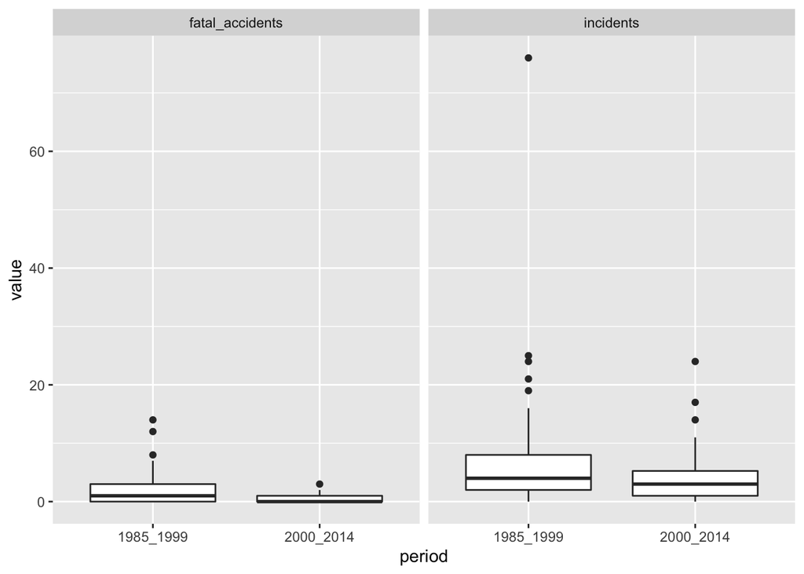

   ```r
   ggplot(subset(data, type != "fatalities"), aes(x = period, y = value))+
     geom_boxplot()+
     facet_wrap(~type)
   ```

4. Over 2000-2014 period, what are the top 3 companies (meaning the worst companies) in terms of fatalities?

   ```r
   data %>%
     filter(type == "fatalities" & period == "2000_2014") %>%
     arrange(desc(value)) %>%
     head(3)
   ```

   ```
   ##             airline avail_seat_km_per_week       type value    period
   ## 1 Malaysia Airlines             1039171244 fatalities   537 2000_2014
   ## 2         American*             5228357340 fatalities   416 2000_2014
   ## 3        Air France             3004002661 fatalities   337 2000_2014
   ```

5. Do the same taking into account the “avail_seat_km_per_week” variable, i.e. analyse “fatalities per `avail_seat_km_per_week`”? Do you obtain the same ranking of airlines?

   ```r
   data %>%
     filter(type == "fatalities" & period == "2000_2014") %>%
     arrange(desc(value/avail_seat_km_per_week)) %>%
     head(3)
   ```

   ```
   ##             airline avail_seat_km_per_week       type value    period
   ## 1     Kenya Airways              277414794 fatalities   283 2000_2014
   ## 2 Malaysia Airlines             1039171244 fatalities   537 2000_2014
   ## 3          Gulf Air              301379762 fatalities   143 2000_2014
   ```

6. Bonus : Measuring a ratio of risk. Assume that, in your whole life, you will fly on average 2000 km every year during 50 years (~ 1 Paris - New-York every five years).
   1. The number of fatalities given in the dataset correspond to periods of 15 years. However the `avail_seat_km_per_week` variable is normalized by week, so create a new variable `value_by_week` normalizing values by week.

      ```r
      data$value_by_week = data$value/(15*52)
      ```

   2. In a new dataset, create a `risk` variable giving the risk you have to be in a “dead seat” during your life based on the safety records of each company in the period 2000-2014.

      ```r
      risk_data = data %>%
        filter(type == "fatalities" & period == "2000_2014") %>%
        mutate(risk = value_by_week/avail_seat_km_per_week*2000*50) %>%
        select(airline,risk)
      ```

   3. Express this risk as “one chance over … to die” for each company. What are the level of risk associated to the top 3 most dangerous companies?

      ```r
      risk_data %>%
        mutate(risk_bis = 1/risk) %>%
        arrange(risk_bis) %>%
        head(3)
      ```

      ```
      ##             airline         risk  risk_bis
      ## 1     Kenya Airways 1.307863e-04  7646.061
      ## 2 Malaysia Airlines 6.625102e-05 15094.107
      ## 3          Gulf Air 6.083134e-05 16438.896
      ```

[^1]: The original dataset has been reshaped for the purpose of the course.